# Cuestiones Seminario 1

Bioestadística

4/24/2020

## Cuestiones a responder en el cuaderno de campo

### Discusión del sobre el aumento de la mortalidad en la Comunidad Valenciana

[output not shown]

A partir de los datos de mortalidad diarios en la Comunidad Valenciana en los años 2019-2020 generamos las siguientes gráficas:

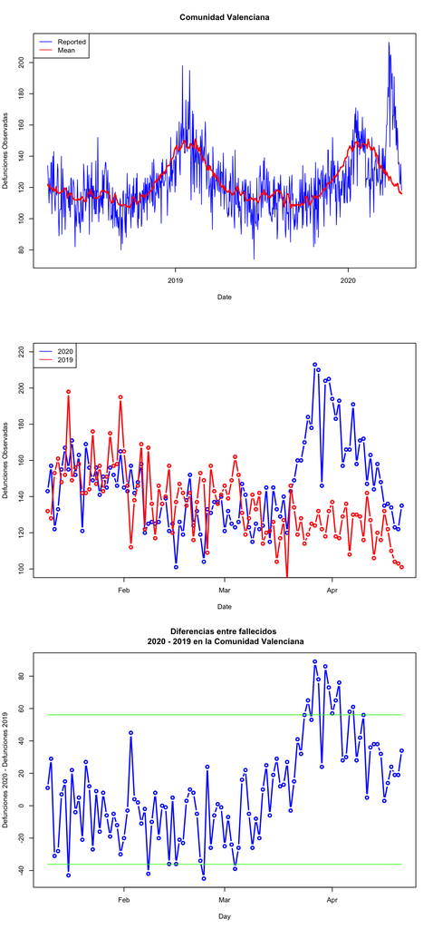

### Cuestiones a responder en el cuaderno de campo:

- ¿Qué representan cada una de las gráficas anteriores?
- ¿Qué tipo de información podemos extraer de cada una de ellas?
- ¿Que conclusiones podemos extraer acerca del impacto de la pandemia provocada por el COVID-19 en la población de la Comunidad Valenciana?
- ¿Qué otro tipo de pruebas podemos efectuar con estos datos para ampliar el conocimiento del impacto que la pandemia tiene en la población de la Comunidad Valenciana?

### Acerca del formato de datos CSV

Os propongo el siguiente ejercicio. Consiste en crear una pequeña base de datos en un fichero que podéis llamar covid19_cv.csv donde incluyáis los datos siguientes:

- Fecha
- Casos Reportados
- Fallecidos
- Hospitalizados
- Casos en UCI
- Recuperados

- ¿Qué información podemos extraer de este conjunto de datos?
- ¿Que variables podemos definir a partir de este conjunto de datos, y de que tipo son?
- ¿Cómo podemos emplear estas variables para extraer información de los datos?